# Eine Veloroute planen

Author

Simone Dordoni

#### Modularbeit Angewandte Geoinformatik, HS23

## Einführung

Ziel dieser Arbeit ist das Finden einer passenden Veloroute in einem Netzwerk aufgrund verschiedener Kriterien.

Es ist geplant, eine Route auf den offiziellen, markierten Radwegen von Schweizmobil (Veloland, Mountainbikeland) zwischen einem Start- und einem Endpunkt in der Schweiz zu finden. Als Kriterium zur Auswahl der bestpassenden Route wurde die Durchquerung von Waldregionen gewählt. Durch eine Gewichtung in einem Dijkstra-Algorithmus ist vorgesehen, Strecken ohne Walddurchquerung zu benachteiligen. Ausserdem sollte das Gefälle der Strecken in der Schätzung der Fahrtzeit berücksichtigt werden.

## Geplante Arbeitsschritte

- Aus den vorhandenen Daten über Strecken einen Netzwerk erstellen
- Zu den Knotenpunkten des Netzwerks Hohenangaben hinzufügen; anschliessend Gefälle pro Teilstrecke berechnen und im Netzwerk als Attribut speichern
- Aufgrund der Daten über Waldflächen den fürs Projekt passenden Waldgebiet generieren; das Waldgebiet mit dem Netzwerk überschineiden; Informationen über die Strecken, die sich im Waldgebiet befinden, speichern.
- Netzwerkanalyse mittels Dijkstra-Algorithmus ausführen. Strecken ohne Wald bzw. mit zu hohem Gefälle benachteiligen.

## Vorgehen und Ergebnisse

In der unterstehenden Tabelle werden die angewendete Datensätze aufgelistet.

Verwendete Datensätze

| Name | Datentyp | Herkunft | Koordinatensystem | Beschreibung |
| --- | --- | --- | --- | --- |
| Digitales Höhenmodell DHM25/200 | Raster .asc | Bundesamt für Landestopografie swisstopo | LV03 LN02 | Die Datei enthält keine Angaben zum koordinatensystem |
| Topografisches Landschaftsmodell swiss TLM 3D - Datensatz Bodenbedeckung | .shp | Bundesamt für Landestopografie swisstopo | LV95 | Der Datensatz Bodenbedeckung enthält Angaben über Waldareal als Polygone. Der Datensatz deckt die ganze Schweiz und ist in zwei Teilen (Ost und West) geteilt. |
| Radwege Veloland und Mountainbikeland | .gdb | Bundesamt für Strassen (ASTRA) und Kantone | LV95 | Der Datensatz enthält glücklicherweise Höhenangaben |
| Waldareal Kanton Zürich | gpkg | Kt. ZH | LV95 | Dieser Datesatz wurde eingesetzt, als das Modell von der ganzen Schweiz zum Kt. ZH reduziert wurde. |
| Velonetz Alltag Kt. ZH | .shp | Kt. ZH | LV95 | Dieser Datesatz wurde eingesetzt, als das Modell von der ganzen Schweiz zum Kt. ZH reduziert wurde. |
| Schweizmobil Routen, Layer Velorouten | gpkg | Kt. ZH | LV95 | Dieser Datesatz wurde eingesetzt, als das Modell von der ganzen Schweiz zum Kt. ZH reduziert wurde. |

Es wurde mit Visual Studio Code gearbeitet und die Befehle wurden jeweils mithilfe vom GitHub Copilot gefunden und überprüft. Als Programmiersprache wurde Python3 eingesetzt. Um die Waldflächen war geplant, einen Buffer von 30m zu erstellen. In diesem Programm gelten Strecken, die in einem Abstand von bis 30m von der Waldgrenze verlaufen, immer noch als im Waldgebiet. Der ursprüngliche Plan scheiterte an der Bearbeitung grosser Datensätze. Probleme wurden bereits mit der Herstellung von Buffern und der Anwendung von “Dissolve”. Das grösste Problem war, die Waldgebiete mit dem Netzwerk zu überschneiden. Die Datenmengen waren möglicherweise zu gross und überschreiteten die Rechenleistung meiner Maschine. Es wurde auch mit der Hälfte bzw. einem Viertel der Schweiz versucht; es wurde auch versucht, den Befehl für die Überschneidung in mehreren Zwischenschritten zu teilen. Dennoch blieben diese Versuche erfolgslos. Auf diesem Grund wurde entschieden, das Projekt auf den Kanton Zürich zu reduzieren. Mit dem Velonetz Alltag konnte das Schweizmobil-Netz sinnvoll ergänzt werden, sonst wäre dies zu wenig dicht, um überhaupt Routen aussuchen zu können.

Der Code fängt mit dem Abrufen von Packages

```python
import pandas as pd
import geopandas as gpd
import networkx as nx
import folium
from folium import plugins
from shapely.ops import unary_union
from shapely.geometry import MultiLineString
import pickle
import matplotlib.pyplot as plt
import matplotlib
```

Anschliessend werden die Velorouten geladen. Einge Befehle werden angegeben, um die Datentabellen anzuschauen und zu überprüfen. Die Daten wurden auf Karten visualisiert (hier nicht wiedergeben).

```python
gdb_pfad01 = 'C:\\dati\\zhaw\\AGI\\Leistungsnachweis Modularbeit\\GIS\\Quellen\\KantonZH\\SchweizMobil-Routen_-OGD.gpkg'
gdf_veloland = gpd.read_file(gdb_pfad01)

#print(gdf_veloland.columns)

gdb_pfad02 = 'C:\\dati\\zhaw\\AGI\\Leistungsnachweis Modularbeit\\GIS\\Quellen\\KantonZH\\Velonetz_Alltag_-OGD\\OGD_VELO_ALLTAG_NETZ_L_M.shp'
gdf_Vatg = gpd.read_file(gdb_pfad02)

# Create the first map
map1 = folium.Map(location=[47.36667, 8.55], zoom_start=13, tiles="cartodbpositron")
folium.GeoJson(gdf_veloland).add_to(map1)
map1.save("outputmap01.html")  # Save the first map as an HTML file

# Create the second map
map2 = folium.Map(location=[47.36667, 8.55], zoom_start=13, tiles="cartodbpositron")
folium.GeoJson(gdf_Vatg).add_to(map2)
map2.save("outputmap02.html")  # Save the second map as an HTML file
```

Die unterschiedlichen Netzwerke werden vereinigt. Diese Daten enthalten leider keine Höhenangabe. Das gesamte Netz als Geodataframe wurde explodiert und mittels des Befehls unary_union in einem einzelnen Element (MultiLineString) vereinigt. Anschliessend war es möglich, alle Linienelemente des Netzwerkes bei Kreuzungen zu unterbrechen. Es wurde geprüft, ob das Geodataframe ein zugewiesenes Koordinatensystem hatte.

```
Index(['RW_KEY', 'RW_KEY_NR', 'KMMIN', 'KMMAX', 'LAENGE_M', 'ROUTENTYP',
       'SHAPE_LEN', 'geometry', 'VERBINDUNG', 'ZWECK', 'FAHRRICHTU',
       'PLANUNGSTY'],
      dtype='object')
EPSG:2056
```

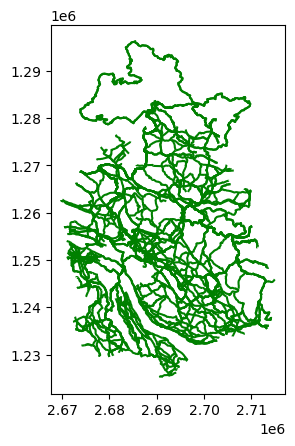

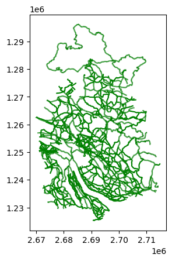

```python
# Combine the GeoDataFrames
VL_Vatg_gdf = pd.concat([gdf_veloland, gdf_Vatg], ignore_index=True)

print(VL_Vatg_gdf.columns)

#prüfen, ob die Daten Höhenangaben enthalten
pd.set_option('display.max_colwidth', 500)
#print(VL_Vatg_gdf['geometry'].head())

exploded_gdf = VL_Vatg_gdf.explode()
exploded_gdf = exploded_gdf.reset_index(drop=True)

#print(exploded_gdf['geometry'].head())
print(exploded_gdf.crs)

fig, ax = plt.subplots()

# Plot the exploded
exploded_gdf.plot(ax=ax, color='green')

plt.show()

from shapely.ops import unary_union

# Dissolve all the geometries into a single MultiLineString
merged = unary_union(exploded_gdf.geometry)

# Split the MultiLineString into individual LineStrings at each intersection
split_lines = unary_union(merged)

# Create a new GeoDataFrame from the split LineStrings
exploded_gdf = gpd.GeoDataFrame(geometry=[line for line in split_lines.geoms])

#print(exploded_gdf['geometry'].head())

fig, ax = plt.subplots()

# Plot the exploded
exploded_gdf.plot(ax=ax, color='green')

plt.show()
```

Anhand des aufbereiteten Netzwerkes wurde das Graph erstellt, um Netzwerkanalyse zu ermöglichen. Im folgenden Abschnitt des Codes wurden die Knoten und Kanten des Netzwerkes aus dem Geodataframe generiert. Um später das Gefälle zu berechnen, wurde ein Attribut an den Kanten hinzugefügt, um deren Länge als explizite Zahl zu speichern.

```python
import networkx as nx
from shapely.geometry import LineString

# Create a graph from the GeoDataFrame
G = nx.Graph()

for line in exploded_gdf['geometry']:
    for point in line.coords:
        G.add_node(point)

for line in exploded_gdf['geometry']:
    for i in range(len(line.coords) - 1):
        # Create a LineString object for the edge
        edge_line = LineString([line.coords[i], line.coords[i + 1]])

        # Calculate the length of the edge
        length = edge_line.length

        # Add the edge to the graph with the length as an attribute
        G.add_edge(line.coords[i], line.coords[i + 1], length=length)
```

Weil das Netzwerk noch keine Höhenangaben aufweist, werden diese Informationen dem digitalen Höhenmodell DHM 25/200 entnommen. Diesem Datensatz wurde zuerst mit einer anderen GIS-Anwendung das korrekte, ursprüngliche Koordinatensystem LV03 zugewiesen und auf das aktuelle Schweizer System LN95 projiziert. Das Höhenmodell betrifft die ganze Schweiz und es wurde deshalb grob auf dem Kanton Zürich reduziert.

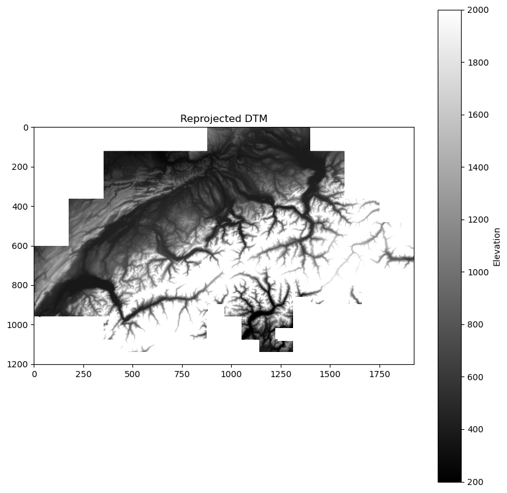

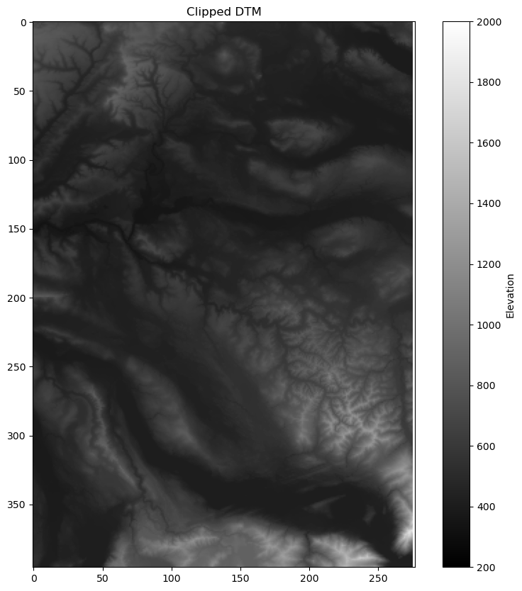

```python
import matplotlib.pyplot as plt
import rasterio

# Open the reprojected DTM
with rasterio.open('C:\\dati\\zhaw\\AGI\\Leistungsnachweis Modularbeit\\GIS\\Quellen\\DHM25-200\\DHM200_X.tif') as src:
    img = src.read(1)

# Plot the DTM
plt.figure(figsize=(10,10))
plt.imshow(img, cmap='gray', vmin=200, vmax=2000)
plt.colorbar(label='Elevation')
plt.title('Reprojected DTM')
plt.show()

import rasterio
from rasterio.mask import mask
from shapely.geometry import box

# Define the extents
minx, miny = 2670520.0, 1220180.0
maxx, maxy = 2725720.0, 1299260.0

# Create a box from the extents
bbox = box(minx, miny, maxx, maxy)

# Open the DTM
with rasterio.open('C:\\dati\\zhaw\\AGI\\Leistungsnachweis Modularbeit\\GIS\\Quellen\\DHM25-200\\DHM200_X.tiff') as src:
    # Clip the DTM
    out_image, out_transform = mask(src, [bbox], crop=True)
    out_meta = src.meta.copy()

# Update the metadata
out_meta.update({
    "driver": "GTiff",
    "height": out_image.shape[1],
    "width": out_image.shape[2],
    "transform": out_transform,
})

# Write the clipped DTM to a new file
with rasterio.open('C:\\dati\\zhaw\\AGI\\Leistungsnachweis Modularbeit\\GIS\\Quellen\\DHM25-200\\DHM200_clipped.tiff', "w", **out_meta) as dest:
    dest.write(out_image)

# Open the reprojected DTM
with rasterio.open('C:\\dati\\zhaw\\AGI\\Leistungsnachweis Modularbeit\\GIS\\Quellen\\DHM25-200\\DHM200_clipped.tiff') as src:
    img = src.read(1)

# Plot the DTM
plt.figure(figsize=(10,10))
plt.imshow(img, cmap='gray', vmin=200, vmax=2000)
plt.colorbar(label='Elevation')
plt.title('Clipped DTM')
plt.show()
```

Den Knoten des Graphs resp. des Netzwerks wurden Höhenangaben hinzugefügt aufgrund des Abgleichens mit dem digitalen Höhenmodell. Anhand der Hohe der Knonten und der Länge der Netzwerkkante, wurde das Gefälle jeder Kante gerechnet. Dabei wurde die Fahrtrichtung mitberücksichtigt. Dieser Schritt erfolgte gemäss der unterstehenden Code-Abschnitt.

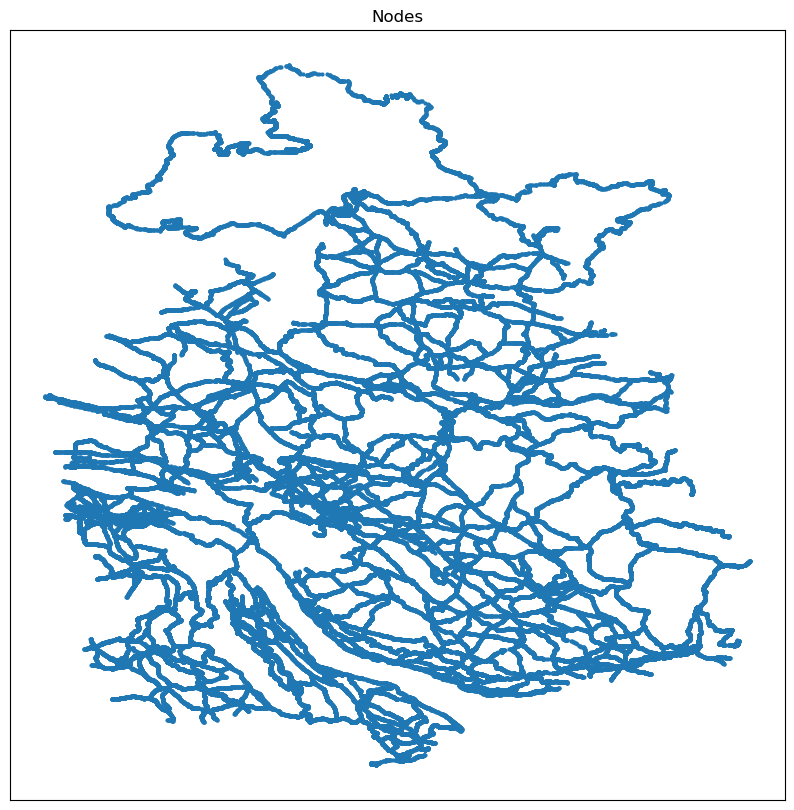

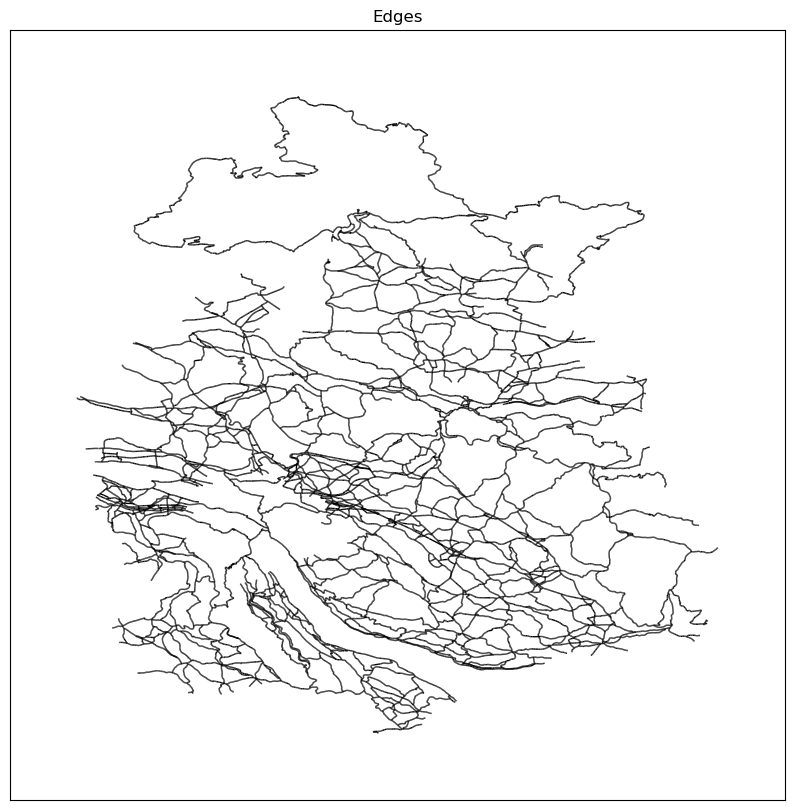

```python
# Open the DTM
with rasterio.open('C:\\dati\\zhaw\\AGI\\Leistungsnachweis Modularbeit\\GIS\\Quellen\\DHM25-200\\DHM200_clipped.tiff') as src:
    # Assign elevations to the nodes
    for node in G.nodes():
        x, y = node
        row, col = src.index(x, y)
        elevation = src.read(1)[row, col]
        G.nodes[node]['elevation'] = elevation

import matplotlib.pyplot as plt
import networkx as nx

# Extract nodes and edges
nodes = G.nodes(data=True)
edges = G.edges()

# Create a dictionary of positions
pos = {node: (node[0], node[1]) for node in G.nodes()}

# Plot nodes
plt.figure(figsize=(10,10))
nx.draw_networkx_nodes(G, pos, node_size=4)
plt.title('Nodes')
plt.show()

# Remove edges that refer to non-existent nodes
edges = [(u, v) for u, v in G.edges() if u in pos and v in pos]

# Plot edges
plt.figure(figsize=(10,10))
nx.draw_networkx_edges(G, pos, edgelist=edges)
plt.title('Edges')
plt.show()

# Get the data of the first few edges
# first_edges = list(G.edges(data=True))[:5]

# Print the data
# for edge in first_edges:
#    print(edge)

# Iterate over the edges
for (node1, node2, data) in G.edges(data=True):
    # Get the elevation of the nodes
    elevation1 = G.nodes[node1]['elevation']
    elevation2 = G.nodes[node2]['elevation']

    # Get the length of the edge
    length = data['length']

    # Calculate the slopes in both directions and store them as edge attributes
    slope1to2 = (elevation2 - elevation1) / length
    slope2to1 = (elevation1 - elevation2) / length
    G[node1][node2]['slope1to2'] = slope1to2
    G[node2][node1]['slope2to1'] = slope2to1

# Get the data of the first few edges
# first_edges = list(G.edges(data=True))[:5]

# Print the data
# for edge in first_edges:
#    print(edge)
```

Es wurde anhand der visuellen Kontrollen als nicht nötig geschätzt, getrennte Nebenbereiche des Netzwerks auszuschliessen. Denn es keine waren sichtbar. Im folgenden Code-Abschnitt wurde der Datensatz über Waldareale in Kt. ZH eingelesen und anhand dessen den Buffer (30m) generiert (Waldgebiet). Waldareal und Waldgebiet wurden auf einer Karte visualisiert.

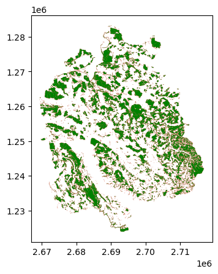

```python
import geopandas as gpd

# Import the shapefile

Wald = gpd.read_file('C:\\dati\\zhaw\\AGI\\Leistungsnachweis Modularbeit\\GIS\\Quellen\\KantonZH\\Waldareal_-OGD.gpkg')

# Create buffers around the geometries
bufferWald = Wald.geometry.buffer(30)

import matplotlib.pyplot as plt

fig, ax = plt.subplots()

# Plot the bufferWald GeoSeries
bufferWald.plot(ax=ax, color='red', alpha=0.5)

# Plot the Wald GeoDataFrame
Wald.plot(ax=ax, color='green')

plt.show()
```

Um weitere Operationen mit dem soeben erstellten Buffer durchzuführen war es nötig, aus den mehreren Objekten nur ein Objekt zu erstellen, um allfällige Überlappungen auszuschliessen. Anschliessend wurde das Ergebnis angezeigt, sowie die Grösse der Flächen (Wald um Buffer) gerechnet, um eine schnelle Prüfung des Zwischenstands durchzuführen.

```
5375
1687
Total area of dissolvedBuffer: 666881321.7205054
Total area of Wald: 499820520.6712451
```

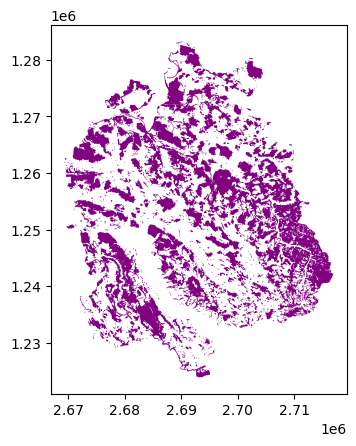

```python
# Dissolve the buffers into a single geometry
# dissolvedBuffer = bufferWald.unary_union

print(len(bufferWald))

import psutil
import sys

# Perform unary_union on the entire GeoSeries to get the dissolved geometry
dissolvedBuffer = bufferWald.unary_union

print(len(dissolvedBuffer.geoms))

import geopandas as gpd

# Create a new GeoSeries that contains the MultiPolygon
dissolvedBuffer_gs = gpd.GeoSeries([dissolvedBuffer])

# Now you can plot the GeoSeries
fig, ax = plt.subplots()  # Create a new figure and axes
dissolvedBuffer_gs.plot(ax=ax, color='purple')
plt.show()  # Display the plot

# Calculate the total area of dissolvedBuffer
dissolvedBuffer_area = dissolvedBuffer.area

# Calculate the total area of Wald
wald_area = Wald.geometry.area.sum()

# Print the areas
print(f"Total area of dissolvedBuffer: {dissolvedBuffer_area}")
print(f"Total area of Wald: {wald_area}")
```

Es wurde versucht, das Waldgebiet mit dem Netzwerk zu überlappen. Die Intersection hatte in früheren Versionen des Codes funktioniert. Als Ergänzungen in den vorherigen Schritten hinzugefügt wurden, konnte der Rechner diese Operation nicht mehr erfolgreich ausführen. In diesem Code-Abschnitt wird auch versucht, bei Überlappungen den Anteil der Teilstrecke zu berechnen, welcher sich mit dem Waldbuffer überlappt.

```python
# Intersect the buffer and the network
intersection = gpd.overlay(edges_gdf, gpd.GeoDataFrame(geometry=[dissolvedBuffer]), how='intersection')

# Calculate the length of each edge and the length of the intersection with the buffer
edges_gdf['length'] = edges_gdf.length
intersection['length'] = intersection.length

# Calculate the percentage of each edge that is inside the buffer
edges_gdf['buffer_percentage'] = intersection['length'] / edges_gdf['length'] * 100

# Iterate over the edges in the graph
for (node1, node2) in G.edges():
    # Get the elevation of the nodes
    elevation1 = G.nodes[node1]['elevation']
    elevation2 = G.nodes[node2]['elevation']

    # Calculate the distance between the nodes
    distance = nx.shortest_path_length(G, node1, node2, weight='distance')
```

Aufgrund der Unmöglichkeit, diese Intersection zu berechnen, wurde einen anderen Weg versucht. Mit dem Befehl sjoin (spatial join) wurde versucht mindestens die Teilstrecken zu markieren, welche eine Überlappung mit dem Waldbuffer haben. Dieses Befehl funktionierte aber nicht. Als Variante wurde also entschieden, einfach die kürzeste Strecke zwischen Start und Ziel zu berechnen, um später Eigenschaften der Route zu berechnen, wie Wald-Durchquerung oder geschätzte Fahrtzeit.  
Beim nächsten Schritt war das Ziel, anhand zwei beliebiger Punkte in Kanton Zürich den kürzesten Weg zu finden. Das Dijkstra-Algorithmus funktioniert anhand der Knoten des ENtuwerks. Es wurde zuerst versucht, die Koordinaten vom Start- und Endpunkt anzugeben und anhand deren die nächstgelegten Knoten vom Netzwerk zu bestimmen. Als Variante wurde auch versucht, mittels Verzeichnis der Ortsnamen von Open Street Map den Start- und Endpunkt zu identifizieren. In beiden Fällen schien ein Problem mit dem Koordinatensystem zu bestehen. Nicht klar war, ob der Graph ein Koordinatensystem aufwies. - Es wurde versucht, einmal dem Graph das Koordinatensystem CH LV95 zuzuweisen, da der Graph anhand von so referenzierten Geodataframes entstand. Anschliessend wurde der Graph zu WGS84 projiziert, um Operationen in Zusammenhang mit OSM zu ermöglichen. Denn OSM entziffetr die Ortsnamen als WGS84-Koordinaten. Hier unten das entsprechende Code. Die Start- und Zielpunkte fanden sich nicht im Untersuchungsgebiet.

```python
from shapely.geometry import LineString

# Convert the edges of the network to LineString objects and add them to a GeoDataFrame
edges = [LineString([n1, n2]) for n1, n2 in G.edges()]
edges_gdf = gpd.GeoDataFrame(geometry=edges)

import pyproj

# Define the source CRS (EPSG:2056) and the target CRS (EPSG:4326)
source_crs = pyproj.CRS("EPSG:2056")
target_crs = pyproj.CRS("EPSG:4326")

# Define the transformation function
transform = pyproj.Transformer.from_crs(source_crs, target_crs, always_xy=True).transform

# Apply the transformation to each node in the graph
G_wgs84 = nx.Graph()
for node in G.nodes:
    transformed_node = transform(*node)
    G_wgs84.add_node(transformed_node)

# Apply the transformation to each edge in the graph
for edge in G.edges(data=True):
    transformed_edge = (transform(*edge[0]), transform(*edge[1]), edge[2])
    G_wgs84.add_edge(transformed_edge[0], transformed_edge[1], **transformed_edge[2])


# Definition Funktion Suche vom nächstliegenden Knoten
def nearest_node(G_wgs84, coords):
    nodes = np.array(list(G.nodes()))
    distances = np.sqrt((nodes[:, 0] - coords[0])**2 + (nodes[:, 1] - coords[1])**2)
    nearest_node = nodes[distances.argmin()]
    return tuple(nearest_node)


import osmnx as ox

# Get the coordinates of the start and end locations
start_gdf = ox.geocode_to_gdf('Zurich') # 'Start Location Name'
end_gdf = ox.geocode_to_gdf('Eglisau') # 'End Location Name'

# Get the nodes closest to the centroids of the start and end locations
start_node = nearest_node(G_wgs84, (start_gdf.geometry[0].centroid.y, start_gdf.geometry[0].centroid.x))
end_node = nearest_node(G_wgs84, (end_gdf.geometry[0].centroid.y, end_gdf.geometry[0].centroid.x))

# Find the shortest path between the start and end nodes
path = nx.shortest_path(G_wgs84, start_node, end_node, weight='length')

# Check the start and end nodes
print(start_node)
print(end_node)

# Check the start and end dataframes
print(start_gdf)
print(end_gdf)
```

- Es wurde versucht, dem Graph kein Koordinatensystem zuzuweisen, um zu schauen, ob evtl. der Programm funktioniert. Das war auch nicht der Fall.

```python
from shapely.geometry import LineString

# Convert the edges of the network to LineString objects and add them to a GeoDataFrame
edges = [LineString([n1, n2]) for n1, n2 in G.edges()]
edges_gdf = gpd.GeoDataFrame(geometry=edges)

import networkx as nx
import osmnx as ox
from osmnx import distance

# Definition Funktion Suche vom nächstliegenden Knoten
def nearest_node(G, coords):
    nodes = np.array(list(G.nodes()))
    distances = np.sqrt((nodes[:, 0] - coords[0])**2 + (nodes[:, 1] - coords[1])**2)
    nearest_node = nodes[distances.argmin()]
    return tuple(nearest_node)

# Get the coordinates of the start and end locations
start_gdf = ox.geocode_to_gdf('Zurich') # 'Start Location Name'
end_gdf = ox.geocode_to_gdf('Eglisau') # 'End Location Name'

# Get the nodes closest to the centroids of the start and end locations
start_node = nearest_node(G, (start_gdf.geometry[0].centroid.y, start_gdf.geometry[0].centroid.x))
end_node = nearest_node(G, (end_gdf.geometry[0].centroid.y, end_gdf.geometry[0].centroid.x))

# Find the shortest path between the start and end nodes
path = nx.shortest_path(G, start_node, end_node, weight='length')

# Check the start and end nodes
print(start_node)
print(end_node)

# Check the start and end dataframes
print(start_gdf)
print(end_gdf)
```

Die folgende Berechnungsschritte wurden nicht ausgeführt. Ihre Funktion ist: - Länge der kürzesten Strecke berechnen - Anhand von 2 Geschwindigkeiten (Ebene, Bergauf) die Fahrtzeit schätzen - Route mit Waldbuffer überschneiden und berechnen, wie lang der Anteil der Route im Waldgebiet ist.

```python
# Calculate the total length of the path
length = sum(G[node1][node2]['length'] for node1, node2 in zip(path[:-1], path[1:]))
print(f"Total length of the path: {length} meters")

# Define the speeds
speed1 = 18  # Speed for slope <= 3% [km/h]
speed2 = 10   # Speed for slope > 3% [km/h]

# Calculate the time needed to travel the path
time = 0
for i in range(len(path) - 1):
    node1 = path[i]
    node2 = path[i+1]
    length = G[node1][node2]['length']
    slope = G[node1][node2]['slope1to2'] if node1 < node2 else G[node1][node2]['slope2to1']
    speed = speed1 if abs(slope) <= 0.03 else speed2
    time += length / speed * 0.06 # m / (km/h) * 0.001 km/m * 60 min/h = min

print(f"Fahrzeit auf der Strecke: {time} Minuten")

# Calculate the percentage of the path that intersects with the buffer
path_edges_gdf = edges_gdf.loc[path]
intersection = gpd.overlay(path_edges_gdf, dissolvedBuffer, how='intersection')
percentage = intersection.length.sum() / path_edges_gdf.length.sum() * 100

print(f"Percentage of the path that intersects with the buffer: {percentage}%")
```

## Schlussfolgerung

Der vorhandene Programm ist nicht in der Lage, das Projektziel umzusetzen. Auch Vereinfachungen des Programms führten nicht zu bessere Ergebnisse. Während des Programmierens wirkte die mangelnde Kenntniss über Packages und Befehle als Hindernis. Die Dokumentation über die Python-Packages in den entsprechenden Webseiten wirkte häufig kryptisch und hart zu merken. Die Unterstützung durch GitHub-Copilot war wertvoll, einerseits um schneller (Teil-)Ergebnisse zu erreichen, anderseits um komplexeres Code zu verstehen. In der Konzepzion des Projektes hätten solidere Vorkenntnisse über komplexe python-Befehle geholfen, die Arbeit realistisch auszulegen. Das Ziel war möglicherweise zu ambitioniert für die verfügbare Ressourcen. Im Nachhinein ist es klar, dass es nötig ist, der Programm zuerst auf kleinere Datenmengen auszuprobieren. Im Fall einer Netzwerkanalyse hätten bedeutend kleinere Datenmengen möglicherweise kein schlüssiges Netzwerk ergeben. Alles in allem waren die zirka 35 für das Programmieren eingesetzten Stunden lehrreich.